# Лабораторная работа №8

Поиск файлов. Перенаправление ввода-вывода. Просмотр запущенных процессов

Липатников Андрей

1032253853@rudn.ru

Российский университет дружбы народов

2026-10-08

# Информация

## Докладчик

- Липатников Андрей
- Студент Российского университета дружбы народов им. П. Лумумбы
- 1032253853@rudn.ru

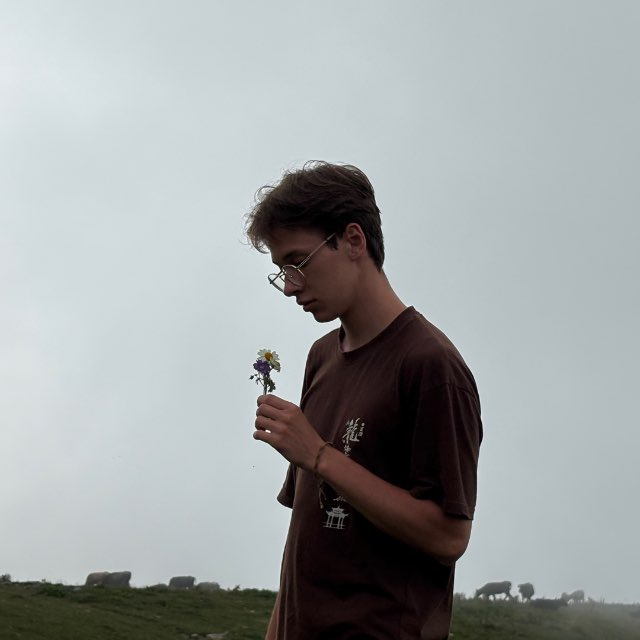

# Вводная часть

## Актуальность

- Поиск и фильтрация — ежедневные задачи администратора
- Перенаправление заменяет десятки ручных операций
- Зависший процесс угрожает стабильности системы

## Цель и задачи

- Цель:
  - Ознакомление с инструментами поиска файлов и фильтрации текстовых данных; практические навыки управления процессами и заданиями, проверки использования диска и обслуживания файловых систем.
- Задачи:
  - Освоить перенаправление потоков ввода-вывода
  - Освоить поиск файлов (`find`) и фильтрацию (`grep`)
  - Освоить запуск в фоне и управление процессами
  - Проверить использование диска (`df`, `du`)
  - Зафиксировать каждый шаг скриншотом

# Материалы и методы

## Среда и методика

- **ОС**: Fedora 41 (Sway) в VirtualBox
- **Терминал**: bash
- **Инструменты**: `find`, `grep`, `ps`, `jobs`, `kill`, `pkill`, `df`, `du`, справочник `man`

# Содержание исследования

## Перенаправление потоков

- `stdin` (0) — ввод, `stdout` (1) — вывод, `stderr` (2) — ошибки

| Оператор | Действие |
| --- | --- |
| `>` | Перезапись файла |
| `>>` | Добавление в конец |
| `2>` | Ошибки в файл |
| `&>` | stdout и stderr вместе |

## Поиск и фильтрация файлов

- `find` — поиск по имени, типу, глубине
- `grep` — фильтрация текста по шаблону
- Конвейер `|` — цепочка фильтров

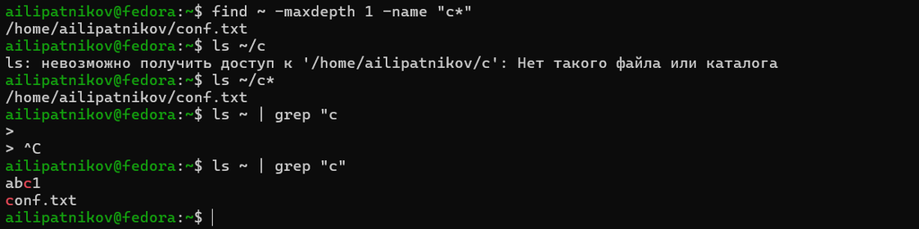

## Процессы и задания

- `gedit &` — запуск в фоновом режиме
- `ps aux | grep gedit` — поиск PID
- `pidof gedit`, `pgrep gedit` — альтернативы
- `kill PID` — завершение процесса

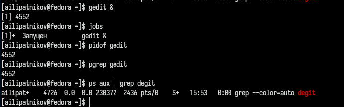

## Проверка использования диска

- `df -h` — размер разделов и свободное место
- `du -sh ~` — объём домашнего каталога

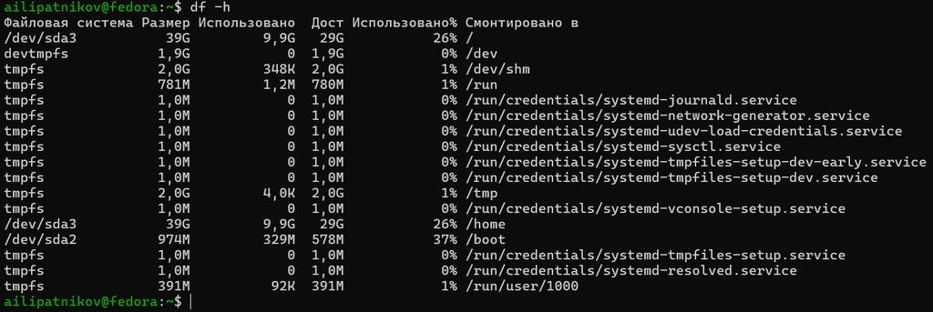

# Результаты

## Полученные результаты

| Результат | Команды |
| --- | --- |
| Перенаправление | `>`, `>>`, `2>`, `&>` |
| Поиск и фильтрация | `find`, `grep`, конвейер |
| Процессы | `ps`, `pidof`, `pgrep`, `jobs` |
| Завершение | `kill`, `pkill` |
| Диск | `df`, `du` |

# Заключение

## Главный вывод

Освоены поиск файлов и фильтрация текстовых данных командами `find` и `grep`, перенаправление потоков ввода-вывода, управление процессами и заданиями (запуск в фоне, определение PID, завершение), проверка использования диска командами `df` и `du`. Эти навыки — основа автоматизации администрирования Linux.

# Резервные слайды

## Резерв: перенаправление потоков

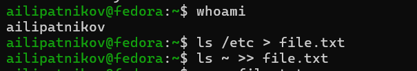

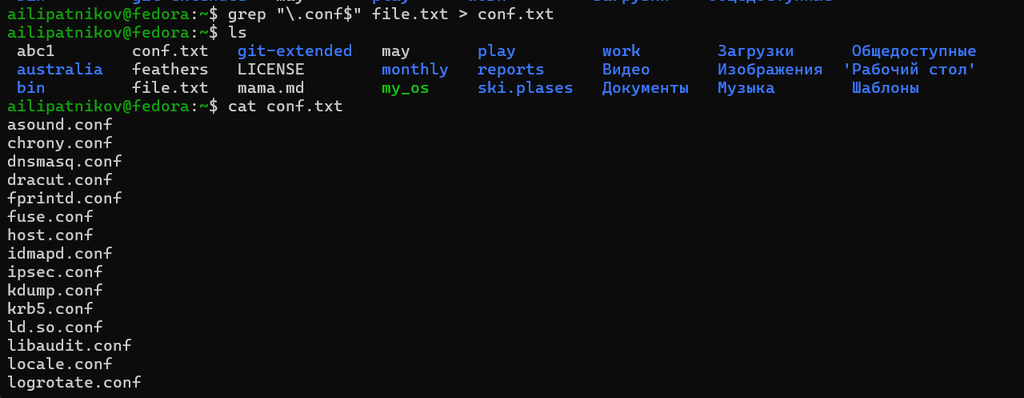

## Резерв: поиск файлов

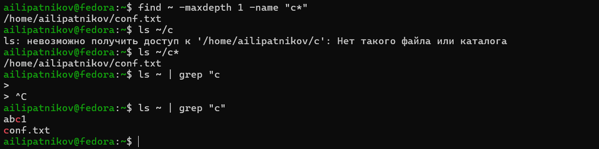

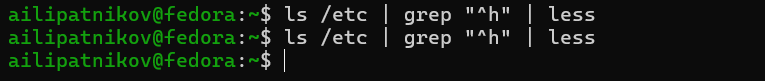

## Резерв: фоновый поиск

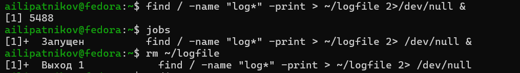

## Резерв: управление процессами

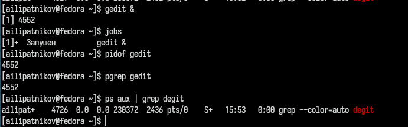

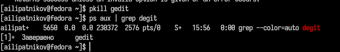

## Резерв: проверка диска

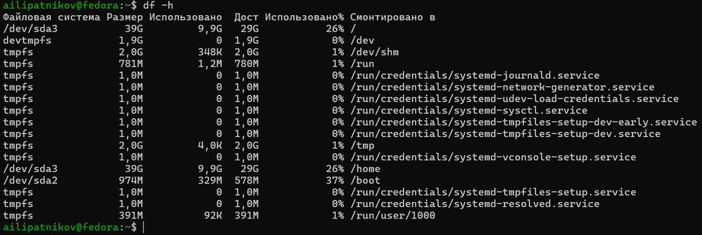

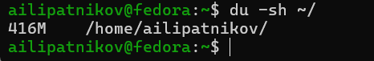

## Резерв: каталоги домашнего дерева

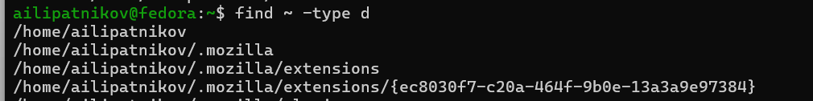